# Final Project: PHTH5210

Ohida Binte Amin

20 April 2024

```r
library(tidyverse)
library(openintro)
library(infer)
library(dplyr)
library(ggplot2)
library(gridExtra)
library(tidyr)
library(corrplot)
library(mice)
library(patchwork)
library(ordinal)
library(MASS)
library("NHANES")
```

### Let’s Explore Data

NHANES data provides a comprehensive overview of demographic, socioeconomic, dietary, health, and lifestyle-related information gathered through interviews, physical examinations, and laboratory tests. This detailed dataset serves as a valuable resource for understanding the U.S. population’s physical and mental health and nutritional status, tracking changes over time, identifying disease prevalence with risk factors, and informing public health policy and programs.

```r
# Insert code
data("NHANES")
print(colnames(NHANES))
```

```
##  [1] "ID"               "SurveyYr"         "Gender"           "Age"
##  [5] "AgeDecade"        "AgeMonths"        "Race1"            "Race3"
##  [9] "Education"        "MaritalStatus"    "HHIncome"         "HHIncomeMid"
## [13] "Poverty"          "HomeRooms"        "HomeOwn"          "Work"
## [17] "Weight"           "Length"           "HeadCirc"         "Height"
## [21] "BMI"              "BMICatUnder20yrs" "BMI_WHO"          "Pulse"
## [25] "BPSysAve"         "BPDiaAve"         "BPSys1"           "BPDia1"
## [29] "BPSys2"           "BPDia2"           "BPSys3"           "BPDia3"
## [33] "Testosterone"     "DirectChol"       "TotChol"          "UrineVol1"
## [37] "UrineFlow1"       "UrineVol2"        "UrineFlow2"       "Diabetes"
## [41] "DiabetesAge"      "HealthGen"        "DaysPhysHlthBad"  "DaysMentHlthBad"
## [45] "LittleInterest"   "Depressed"        "nPregnancies"     "nBabies"
## [49] "Age1stBaby"       "SleepHrsNight"    "SleepTrouble"     "PhysActive"
## [53] "PhysActiveDays"   "TVHrsDay"         "CompHrsDay"       "TVHrsDayChild"
## [57] "CompHrsDayChild"  "Alcohol12PlusYr"  "AlcoholDay"       "AlcoholYear"
## [61] "SmokeNow"         "Smoke100"         "Smoke100n"        "SmokeAge"
## [65] "Marijuana"        "AgeFirstMarij"    "RegularMarij"     "AgeRegMarij"
## [69] "HardDrugs"        "SexEver"          "SexAge"           "SexNumPartnLife"
## [73] "SexNumPartYear"   "SameSex"          "SexOrientation"   "PregnantNow"
```

```r
print(head(NHANES))
```

```
## # A tibble: 6 × 76
##      ID SurveyYr Gender   Age AgeDecade AgeMonths Race1 Race3 Education
##   <int> <fct>    <fct>  <int> <fct>         <int> <fct> <fct> <fct>
## 1 51624 2009_10  male      34 " 30-39"        409 White <NA>  High School
## 2 51624 2009_10  male      34 " 30-39"        409 White <NA>  High School
## 3 51624 2009_10  male      34 " 30-39"        409 White <NA>  High School
## 4 51625 2009_10  male       4 " 0-9"           49 Other <NA>  <NA>
## 5 51630 2009_10  female    49 " 40-49"        596 White <NA>  Some College
## 6 51638 2009_10  male       9 " 0-9"          115 White <NA>  <NA>
## # ℹ 67 more variables: MaritalStatus <fct>, HHIncome <fct>, HHIncomeMid <int>,
## #   Poverty <dbl>, HomeRooms <int>, HomeOwn <fct>, Work <fct>, Weight <dbl>,
## #   Length <dbl>, HeadCirc <dbl>, Height <dbl>, BMI <dbl>,
## #   BMICatUnder20yrs <fct>, BMI_WHO <fct>, Pulse <int>, BPSysAve <int>,
## #   BPDiaAve <int>, BPSys1 <int>, BPDia1 <int>, BPSys2 <int>, BPDia2 <int>,
## #   BPSys3 <int>, BPDia3 <int>, Testosterone <dbl>, DirectChol <dbl>,
## #   TotChol <dbl>, UrineVol1 <int>, UrineFlow1 <dbl>, UrineVol2 <int>, …
```

### Let’s Generate a Research Question

Depression is a prevalent mental health concern among adults due to relentless societal pressures. Examining the nature and dynamics of physical attributes, demographics, lifestyle, or behavioral experiences can help us better characterize the correlates of psychological depression. Investigating lifestyle patterns, demographic information, and physical measurements has the potential to identify the correlates with different severity levels of depression. Focus on sustained interpersonal mental health might be especially helpful in identifying individuals at heightened risk for psychopathology. I am interested in the following research question:

#### RQ: What is the relationship between physical, demographic, or lifestyle factors and the prevalence of depressive symptoms among adults in the United States, as indicated by self-reported days of feeling depressed and little interest in doing things?

To answer this research question, a few hypotheses are provided below:

H1: Regular engagement in physical activity is associated with better mental health outcomes, including reduced feelings of depression.

H2: Higher screen time through watching TV is associated with more days of feeling little interest in doing things.

H3: Alcohol consumption is associated with the prevalence of mental health disorders in adults.

H4: Adults who are married or living with a partner report fewer days of feeling depressed compared to those who are single, divorced, separated, or widowed.

H5: Higher levels of education are associated with lower levels of depression among adults.

H6: Adults with higher income levels report fewer days of feeling depressed compared to those with lower income levels.

H7: Older adults experience fewer days of feeling depressed compared to younger adults.

H8: A higher BMI (Body Mass Index) is associated with an increased likelihood of experiencing depression among adults.

H9: Individuals who report experiencing sleep disturbances, such as trouble falling asleep or staying asleep, are more likely to experience depression.

H10: Adults who perceive their general health as poor are more likely to report symptoms of depression.

### Let’s Observe Associations

First, let’s explore the association between self-reported depression and little interest in doing things using a chi-square test for independence. This test assesses whether there is a significant association between two categorical variables. The chi-squared test showed a significant association (X-squared = 3110.8, df = 4, p < 2.2e-16) between self-reported depression and little interest in doing things. This suggests that individuals reporting more days of feeling depressed are also more likely to report feeling little interest in doing things.

```r
# Insert code
# let's see if there's any association between self-reported depression and little interest in doing things
cont_table <- table(NHANES$Depressed, NHANES$LittleInterest)
chi_square_test <- chisq.test(cont_table)
print(chi_square_test)
```

```
##
##  Pearson's Chi-squared test
##
## data:  cont_table
## X-squared = 3110.8, df = 4, p-value < 2.2e-16
```

```r
# let's focus separately on female and male populations
female_data <- NHANES %>%
  filter(Gender == "female")

male_data <- NHANES %>%
  filter(Gender == "male")

print(paste("Number of rows in female data:", nrow(female_data)))
```

```
## [1] "Number of rows in female data: 5020"
```

```r
print(paste("Number of rows in male data:", nrow(male_data)))
```

```
## [1] "Number of rows in male data: 4980"
```

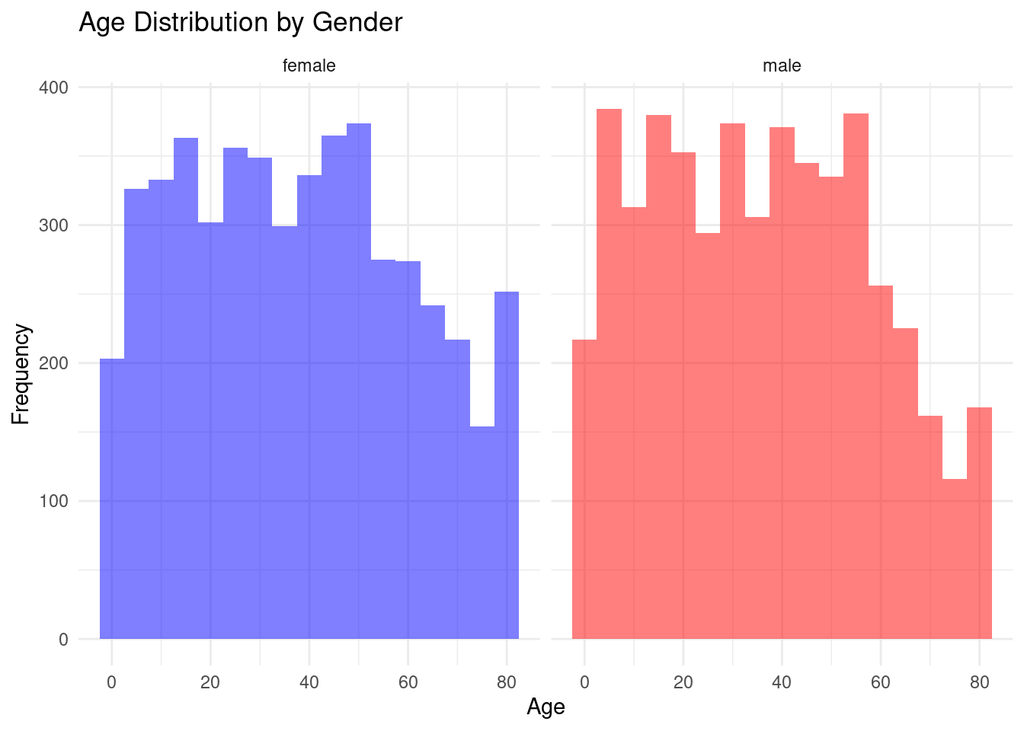

```r
# let's see the distribution of age
ggplot() +
  geom_histogram(data = female_data, aes(x = Age), fill = "blue", alpha = 0.5, binwidth = 5) +
  geom_histogram(data = male_data, aes(x = Age), fill = "red", alpha = 0.5, binwidth = 5) +
  labs(x = "Age", y = "Frequency", title = "Age Distribution by Gender") +
  facet_wrap(~ Gender, ncol = 2) +
  theme_minimal()
```

```r
# let's see the average age
mean_age_female <- mean(female_data$Age, na.rm = TRUE)
mean_age_male <- mean(male_data$Age, na.rm = TRUE)
print(paste("Mean age for females:", round(mean_age_female, 2)))
```

```
## [1] "Mean age for females: 37.64"
```

```r
print(paste("Mean age for males:", round(mean_age_male, 2)))
```

```
## [1] "Mean age for males: 35.83"
```

### Let’s Analyze Data

In our analysis, the dependent variable ‘Depressed’ is the focus, with attention directed towards various lifestyle factors and demographic characteristics serving as independent variables. These include PhysActive and PhysActiveDays (indicative of physical activity), TVHrsDay (reflective of screen time habits), AlcoholDay (associated with alcohol consumption), and SleepHrsNight & SleepTrouble (pertaining to sleep duration and disturbances). Additionally, physical measurements such as BMI, Weight, Pulse, BPSysAve, and BPDiaAve status are considered as independent variables. Lastly, control variables encompass Age, Gender, Education, Poverty, Race3, and HealthGen, allowing for the exploration of the relationship between these factors and the likelihood of experiencing depressive symptoms.

For conducting exploratory data analyses, we will focus on the following data visualizations incorporating multiple variables and interpret the results:

#### Visualization 1: Histograms for Dependent Variables [Depressed | LittleInterest]

#### Interpretation:

For days felt depressed, the majority reported none, indicating a low prevalence of self-acknowledged depressive symptoms. In contrast, ‘Several’ days of depression are less frequently reported, and a smaller proportion of participants feel this way ‘Most’ of the time. A similar distribution is noted for little interest in doing things, with most participants reporting no days of disinterest, suggesting a lower overall burden of these specific mental health concerns in the surveyed population. Notably, there is a non-negligible portion of data categorized as ‘NA’, highlighting potential non-responses or inapplicability in the survey questions related to these mental health states.

#### Visualization 2: Bar Plots for Categorical Independent Variables [Comparing Depressed across different categories such as PhysActive | SleepTrouble]

#### Interpretation:

The bar plot shows a comparison of self-reported depressive symptoms against two lifestyle factors: physical activity and sleep trouble. Individuals who are physically active report fewer days of depression, suggesting a possible link between exercise and better mental health. Conversely, those with sleep trouble more also report experiencing depression, highlighting sleep quality as a potential area of concern for mental well-being. The presence of non-responses (NA) calls for cautious interpretation and underscores the need for comprehensive data collection in mental health studies.

#### Visualization 3: Boxplots for Numerical Independent Variables

#### Interpretation:

The boxplots display the distribution of Weight, BMI, Pulse, and Blood Pressure (both systolic and diastolic averages) across different levels of self-reported depression (None, Several, Most). BMI appears fairly consistent across depression categories, with no large variation in median or range, suggesting BMI may not change much with depression severity. Pulse rates show some variability, particularly a slight increase in median value and difference in range for the ‘Most’ category, which could imply a physiological response associated with more severe depression. Weight is also consistent across categories, indicating it might not be strongly linked with the severity of depression in this sample. Blood pressure readings, both systolic and diastolic, do not exhibit notable differences across depression levels, suggesting no clear association between average blood pressure and self-reported depression severity in this dataset.

#### Visualization 4: Scatter Plots for Associations between Variables

#### Interpretation:

The scatter plots and Pearson correlation coefficients provide insights into the relationships between various numerical variables. For PhysActiveDays and Age, there appears to be a very weak positive correlation, indicating minimal linear association between the number of days of physical activity and age. Similarly, the correlation between PhysActiveDays and SleepHrsNight is also very weak, suggesting little linear relationship between physical activity and sleep duration. In contrast, BPSysAve and BPDiaAve exhibit a moderate positive correlation, indicating a stronger linear relationship between average systolic and diastolic blood pressures.

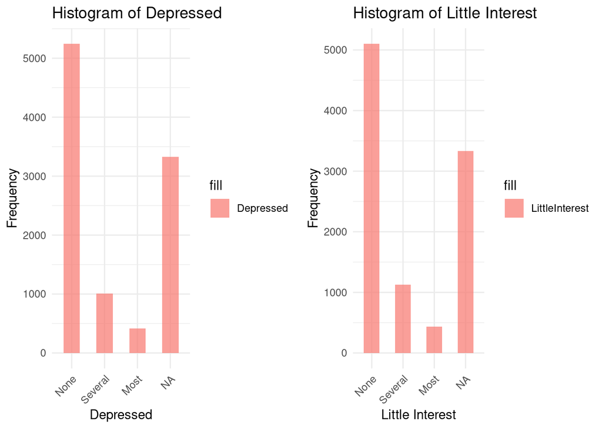

```r
# Insert code
# 1: Histogram of Dependent Variables
hist_depressed <- ggplot(NHANES, aes(x = Depressed, fill = "Depressed")) +
  geom_bar(width = 0.5, position = "dodge", alpha = 0.7) +
  labs(title = "Histogram of Depressed", x = "Depressed", y = "Frequency") +
  theme_minimal() +
  theme(axis.text.x = element_text(angle = 45, hjust = 1))

hist_little_interest <- ggplot(NHANES, aes(x = LittleInterest, fill = "LittleInterest")) +
  geom_bar(width = 0.5, position = "dodge", alpha = 0.7) +
  labs(title = "Histogram of Little Interest", x = "Little Interest", y = "Frequency") +
  theme_minimal() +
  theme(axis.text.x = element_text(angle = 45, hjust = 1))

combined_histogram <- grid.arrange(hist_depressed, hist_little_interest, ncol = 2)
```

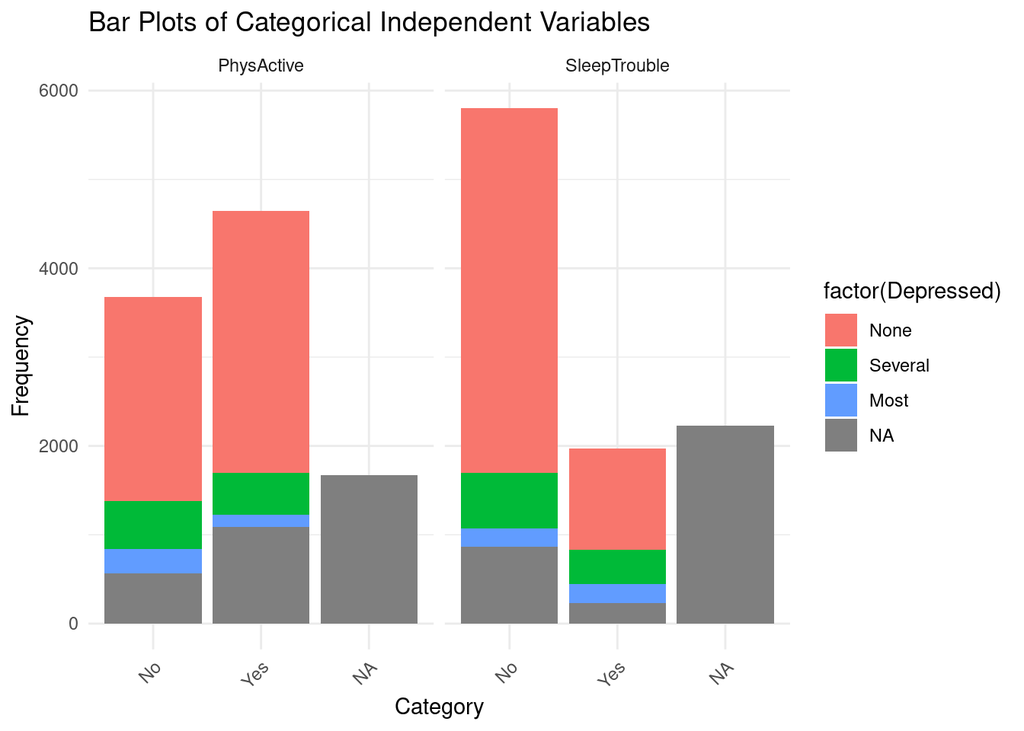

```r
# 2: Bar Plots for Categorical Independent Variables
NHANES_subset_ <- NHANES %>%
  dplyr::select(PhysActive, SleepTrouble, Depressed)

NHANES_long_ <- NHANES_subset_ %>%
  gather(key = "independent_variable", value = "category", -Depressed)

ggplot(NHANES_long_, aes(x = category, fill = factor(Depressed))) +
  geom_bar() +  # Use default position (stacked)
  facet_wrap(~ independent_variable, scales = 'free_x') +
  labs(title = 'Bar Plots of Categorical Independent Variables',
       x = 'Category', y = 'Frequency') +
  theme_minimal() +
  theme(axis.text.x = element_text(angle = 45, hjust = 1))
```

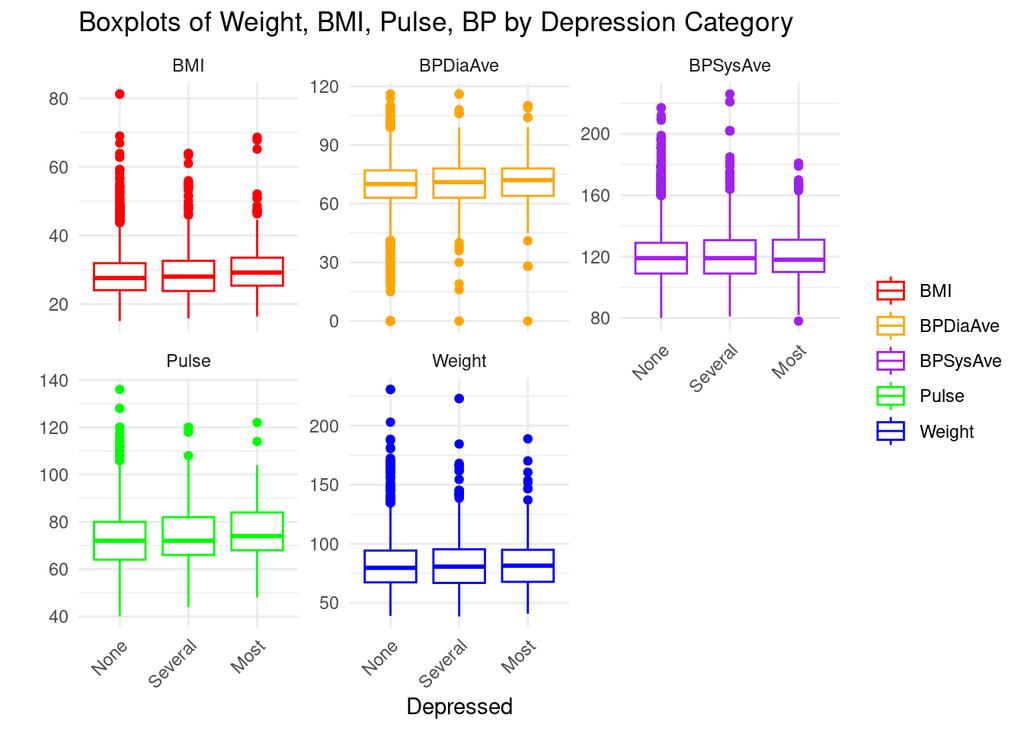

```r
# 3: Boxplots for Numerical Independent Variables
NHANES_subset <- NHANES %>%
  dplyr::select(Weight, BMI, Pulse, BPSysAve, BPDiaAve, Depressed) %>%
  drop_na()

NHANES_long <- NHANES_subset %>%
  pivot_longer(cols = c(Weight, BMI, Pulse, BPSysAve, BPDiaAve),
               names_to = "variable",
               values_to = "value")

ggplot(NHANES_long, aes(x = Depressed, y = value, color = variable)) +
  geom_boxplot() +
  facet_wrap(~variable, scales = "free_y") +
  labs(title = 'Boxplots of Weight, BMI, Pulse, BP by Depression Category', y = "") +
  scale_color_manual(values = c("Weight" = "blue", "BMI" = "red", "Pulse" = "green", "BPSysAve" = "purple", "BPDiaAve" = "orange")) +
  theme_minimal() +
  theme(axis.text.x = element_text(angle = 45, hjust = 1),
        legend.title = element_blank())
```

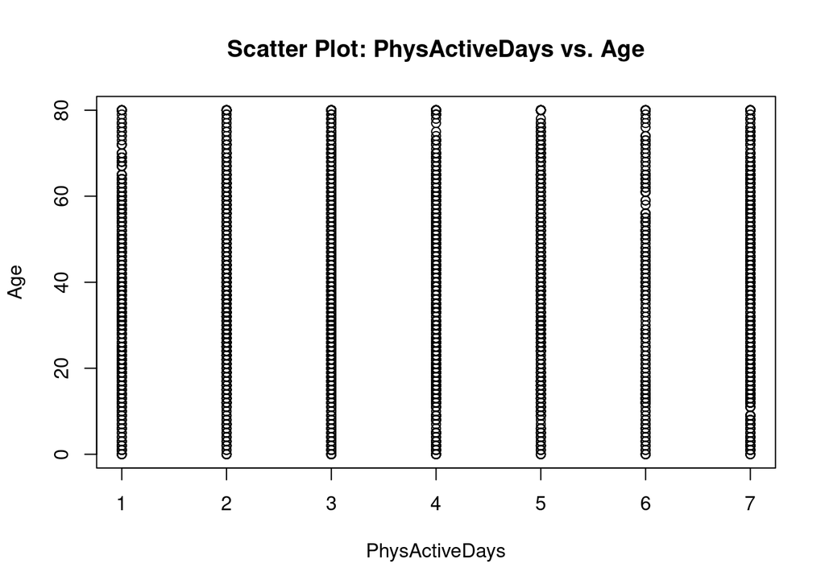

```r
# 4: Scatterplot for Associations between Variables
num_vars <- c("PhysActiveDays", "SleepHrsNight", "Weight", "Age", "BMI", "Pulse", "BPSysAve", "BPDiaAve")

var1 <- "PhysActiveDays"
var2 <- "Age"
data <- na.omit(NHANES[, c(var1, var2)])

# creating the scatter plot
plot(data[[var1]], data[[var2]], xlab = var1, ylab = var2, main = paste("Scatter Plot:", var1, "vs.", var2))
```

```r
# calculating the Pearson correlation coefficient
correlation <- cor(data[[var1]], data[[var2]])
print(paste("Pearson correlation coefficient:", correlation))
```

```
## [1] "Pearson correlation coefficient: 0.0166375574172732"
```

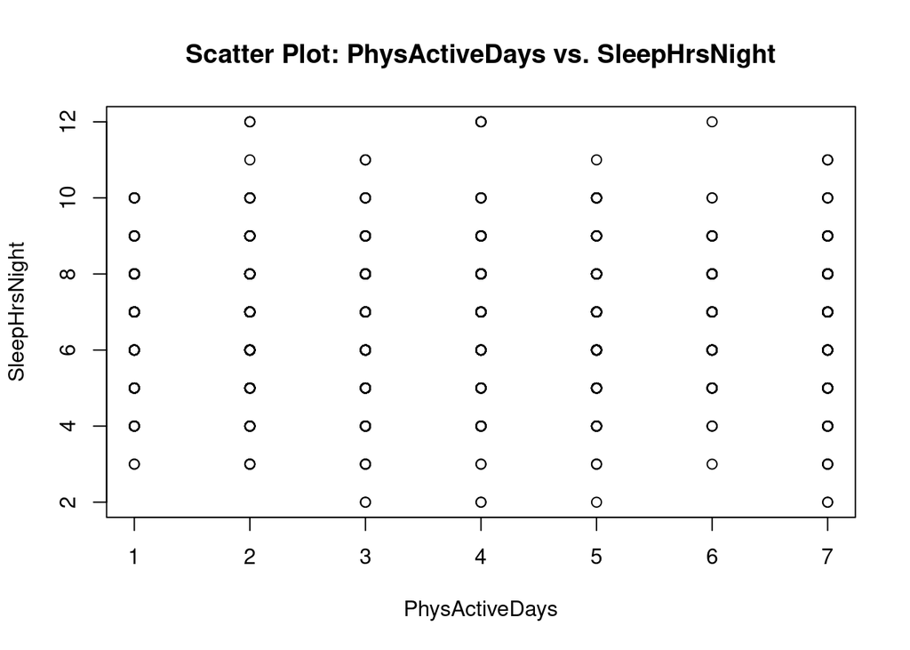

```r
var1 <- "PhysActiveDays"
var2 <- "SleepHrsNight"
data <- na.omit(NHANES[, c(var1, var2)])

# creating the scatter plot
plot(data[[var1]], data[[var2]], xlab = var1, ylab = var2, main = paste("Scatter Plot:", var1, "vs.", var2))
```

```r
# calculating the Pearson correlation coefficient
correlation <- cor(data[[var1]], data[[var2]])
print(paste("Pearson correlation coefficient:", correlation))
```

```
## [1] "Pearson correlation coefficient: 0.0156619604213072"
```

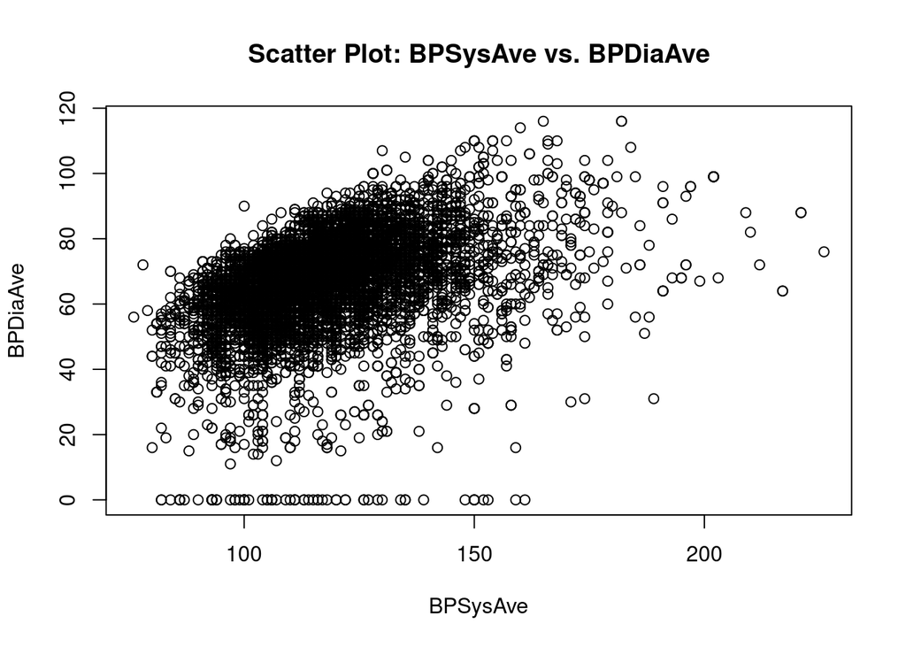

```r
var1 <- "BPSysAve"
var2 <- "BPDiaAve"
data <- na.omit(NHANES[, c(var1, var2)])

# creating the scatter plot
plot(data[[var1]], data[[var2]], xlab = var1, ylab = var2, main = paste("Scatter Plot:", var1, "vs.", var2))
```

```r
# calculating the Pearson correlation coefficient
correlation <- cor(data[[var1]], data[[var2]])
print(paste("Pearson correlation coefficient:", correlation))
```

```
## [1] "Pearson correlation coefficient: 0.400721373122426"
```

### Let’s Further Analyze Data by Fitting Regression Models

The full model includes a comprehensive set of predictors encompassing demographic, lifestyle, and health-related factors, selected based on their potential relevance to the outcome ‘Depressed’. Gender, race, and education represent key demographic variables that may influence mental health status. Marital status and poverty are included for their associations with social support and socioeconomic status, which are known to affect depression. Physical activity, TV hours per day, and alcohol consumption are lifestyle factors that can impact both physical and mental well-being. Sleep-related variables are crucial given the strong link between sleep quality and depression. The inclusion of age, weight, BMI, pulse, and blood pressure provides insight into the role of general health and physiological factors. Finally, self-rated health (HealthGen) serves as a subjective measure of overall health status, which can be a strong indicator of mental health.

The hypotheses and justifications for including each variable:

###### Gender: Depression rates may differ between genders due to biological, psychological, and social variances.

###### Race: Racial background may influence depression due to socioeconomic factors or discrimination.

###### Education: Various education levels may correlate with differing depression levels, possibly influenced by job prospects and social status.

###### Marital Status: Marital status may be associated with depression due to variations in social support and life stressors.

###### Poverty: Individuals in poverty may face higher depression risks due to financial stress.

###### Physical Activity: Physical activity could reduce depression.

###### TV Hours: Increased TV viewing may correlate with higher depression levels due to reduced social interaction and physical activity.

###### Alcohol Use: Alcohol consumption may be linked to depression.

###### Sleep: Sleep quantity and quality may affect depression levels.

###### Weight and BMI: Body weight and BMI may impact depression through health condition and concerns.

###### Age: Depression may be associated with age-related changes, health status, or generational differences.

###### Pulse, Blood Pressure: Physical health indicators may indirectly relate to depression.

###### General Health Perception: Perception of overall health may directly affect depression.

```r
# Insert code
model_full <- polr(as.ordered(Depressed) ~ Gender + Race3 + Education + MaritalStatus + Poverty + PhysActive + PhysActiveDays + TVHrsDay + AlcoholDay + SleepHrsNight + SleepTrouble + Weight + Age + BMI + Pulse + BPSysAve + BPDiaAve + HealthGen, data = NHANES, Hess=TRUE)
print(length(coef(model_full)))
```

```
## [1] 37
```

```r
summary(model_full)
```

```
## Call:
## polr(formula = as.ordered(Depressed) ~ Gender + Race3 + Education +
##     MaritalStatus + Poverty + PhysActive + PhysActiveDays + TVHrsDay +
##     AlcoholDay + SleepHrsNight + SleepTrouble + Weight + Age +
##     BMI + Pulse + BPSysAve + BPDiaAve + HealthGen, data = NHANES,
##     Hess = TRUE)
##
## Coefficients:
##                                Value Std. Error  t value
## Gendermale                -0.2511984   0.272604 -0.92148
## Race3Black                -0.4855093   0.624337 -0.77764
## Race3Hispanic              0.2670652   0.647703  0.41233
## Race3Mexican              -0.1449862   0.627045 -0.23122
## Race3White                 0.3226638   0.549173  0.58754
## Race3Other                 0.0316432   0.793915  0.03986
## Education9 - 11th Grade    1.1784201   0.599267  1.96644
## EducationHigh School       1.3030459   0.574727  2.26724
## EducationSome College      0.5326940   0.574827  0.92670
## EducationCollege Grad      1.0842328   0.598836  1.81057
## MaritalStatusLivePartner   0.4234862   0.374568  1.13060
## MaritalStatusMarried      -0.7115386   0.320874 -2.21750
## MaritalStatusNeverMarried  0.1698251   0.344620  0.49279
## MaritalStatusSeparated     0.6217714   0.532017  1.16871
## MaritalStatusWidowed       0.6196422   0.470291  1.31757
## Poverty                   -0.1963935   0.066758 -2.94186
## PhysActiveYes             -0.4672758   0.206857 -2.25893
## PhysActiveDays            -0.0706351   0.049003 -1.44144
## TVHrsDay0_to_1_hr          0.4495769   0.793146  0.56683
## TVHrsDay1_hr              -0.1198974   0.801875 -0.14952
## TVHrsDay2_hr               0.4541137   0.771582  0.58855
## TVHrsDay3_hr               0.7423146   0.783915  0.94693
## TVHrsDay4_hr               0.8384798   0.799963  1.04815
## TVHrsDayMore_4_hr          1.2636822   0.777976  1.62432
## AlcoholDay                 0.0853440   0.039048  2.18561
## SleepHrsNight             -0.0431194   0.071907 -0.59965
## SleepTroubleYes            1.0911161   0.207100  5.26856
## Weight                     0.0039854   0.013876  0.28722
## Age                       -0.0009111   0.008450 -0.10782
## BMI                       -0.0249481   0.041276 -0.60442
## Pulse                      0.0091849   0.008038  1.14270
## BPSysAve                   0.0005047   0.006912  0.07302
## BPDiaAve                   0.0067423   0.008182  0.82399
## HealthGenVgood             0.3388870   0.422516  0.80207
## HealthGenGood              0.9775934   0.419299  2.33150
## HealthGenFair              1.1468568   0.478379  2.39738
## HealthGenPoor              2.3702025   0.678381  3.49391
##
## Intercepts:
##              Value   Std. Error t value
## None|Several  3.6866  1.6444     2.2419
## Several|Most  5.5308  1.6534     3.3451
##
## Residual Deviance: 999.5547
## AIC: 1077.555
## (8955 observations deleted due to missingness)
```

```r
print(AIC(model_full))
```

```
## [1] 1077.555
```

### Let’s Apply Backward Elimination Process

Now, using a backward elimination process, we will start with all candidate variables and remove the least significant one, refitting the model after each removal of variables to see if the change affects the model’s performance. We will consider a criterion, Akaike’s Information Criterion (AIC) scores to understand the models’ performance.

The analysis involved building several logistic regression models to predict depression status in the NHANES dataset while progressively excluding one variable at a time. Notably, models excluding gender, race, weight, age, BMI, pulse, BPDiaAve, and BPSysAve were found to perform better than the full model, as indicated by lower AIC values. Conversely, models excluding education, marital status, poverty, physical activity, physical activity days, TV hours, alcohol consumption, sleep duration, sleep trouble, and health outcomes did not improve model fit, suggesting that these variables significantly contribute to predicting depression status.

```r
# Insert code
# Let's exclude one variable: gender
model_without_gender <- polr(as.ordered(Depressed) ~ Race3 + Education + MaritalStatus + Poverty + PhysActive + PhysActiveDays + TVHrsDay + AlcoholDay + SleepHrsNight + SleepTrouble + Weight + Age + BMI + Pulse + BPSysAve + BPDiaAve + HealthGen, data = NHANES, Hess=TRUE)
print(length(coef(model_without_gender)))
```

```
## [1] 36
```

```r
if (AIC(model_without_gender) < AIC(model_full)) {
  print("The model without gender is better!")
} else{
  print(AIC(model_without_gender) - AIC(model_full))
  print("The model without gender is not better... ")
}
```

```
## [1] "The model without gender is better!"
```

```r
# Let's exclude one variable: race
model_without_race <- polr(as.ordered(Depressed) ~ Gender + Education + MaritalStatus + Poverty + PhysActive + PhysActiveDays + TVHrsDay + AlcoholDay + SleepHrsNight + SleepTrouble + Weight + Age + BMI + Pulse + BPSysAve + BPDiaAve + HealthGen, data = NHANES, Hess=TRUE)
print(length(coef(model_without_race)))
```

```
## [1] 32
```

```r
if (AIC(model_without_race) < AIC(model_full)) {
  print("The model without race is better!")
} else{
  print(AIC(model_without_race) - AIC(model_full))
  print("The model without race is not better... ")
}
```

```
## [1] "The model without race is better!"
```

```r
# Let's exclude one variable: education
model_without_education <- polr(as.ordered(Depressed) ~ Gender + Race3 +  MaritalStatus + Poverty + PhysActive + PhysActiveDays + TVHrsDay + AlcoholDay + SleepHrsNight + SleepTrouble + Weight + Age + BMI + Pulse + BPSysAve + BPDiaAve + HealthGen, data = NHANES, Hess=TRUE)
print(length(coef(model_without_education)))
```

```
## [1] 33
```

```r
if (AIC(model_without_education) < AIC(model_full)) {
  print("The model without education is better!")
} else{
  print(AIC(model_without_education) - AIC(model_full))
  print("The model without education is not better... ")
}
```

```
## [1] 7.055615
## [1] "The model without education is not better... "
```

```r
# Let's exclude one variable: maritalstatus
model_without_marital <- polr(as.ordered(Depressed) ~ Gender + Race3 + Education + Poverty + PhysActive + PhysActiveDays + TVHrsDay + AlcoholDay + SleepHrsNight + SleepTrouble + Weight + Age + BMI + Pulse + BPSysAve + BPDiaAve + HealthGen, data = NHANES, Hess=TRUE)
if (AIC(model_without_marital) < AIC(model_full)) {
  print("The model without marital-status is better!")
} else{
  print(AIC(model_without_marital) - AIC(model_full))
  print("The model without marital-status is not better... ")
}
```

```
## [1] 18.93709
## [1] "The model without marital-status is not better... "
```

```r
# Let's exclude one variable: poverty
model_without_poverty <- polr(as.ordered(Depressed) ~ Gender + Race3 + Education + MaritalStatus + PhysActive + PhysActiveDays + TVHrsDay + AlcoholDay + SleepHrsNight + SleepTrouble + Weight + Age + BMI + Pulse + BPSysAve + BPDiaAve + HealthGen, data = NHANES, Hess=TRUE)
if (AIC(model_without_poverty) < AIC(model_full)) {
  print("The model without poverty is better!")
} else{
  print(AIC(model_without_poverty) - AIC(model_full))
  print("The model without poverty is not better... ")
}
```

```
## [1] 109.6655
## [1] "The model without poverty is not better... "
```

```r
# Let's exclude one variable: physactive
model_without_physactive <- polr(as.ordered(Depressed) ~ Gender + Race3 + Education + MaritalStatus + Poverty + PhysActiveDays + TVHrsDay + AlcoholDay + SleepHrsNight + SleepTrouble + Weight + Age + BMI + Pulse + BPSysAve + BPDiaAve + HealthGen, data = NHANES, Hess=TRUE)
if (AIC(model_without_physactive) < AIC(model_full)) {
  print("The model without physical activity is better!")
} else{
  print(AIC(model_without_physactive) - AIC(model_full))
  print("The model without physical activity is not better... ")
}
```

```
## [1] 3.107456
## [1] "The model without physical activity is not better... "
```

```r
# Let's exclude one variable: physactiveday
model_without_physactived <- polr(as.ordered(Depressed) ~ Gender + Race3 + Education + MaritalStatus + Poverty + PhysActive + TVHrsDay + AlcoholDay + SleepHrsNight + SleepTrouble + Weight + Age + BMI + Pulse + BPSysAve + BPDiaAve + HealthGen, data = NHANES, Hess=TRUE)
if (AIC(model_without_physactived) < AIC(model_full)) {
  print("The model without physical activity days is better!")
} else{
  print(AIC(model_without_physactived) - AIC(model_full))
  print("The model without physical activity days is not better... ")
}
```

```
## [1] 1257.475
## [1] "The model without physical activity days is not better... "
```

```r
# Let's exclude one variable: tvhours
model_without_tv <- polr(as.ordered(Depressed) ~ Gender + Race3 + Education + MaritalStatus + Poverty + PhysActive + PhysActiveDays + AlcoholDay + SleepHrsNight + SleepTrouble + Weight + Age + BMI + Pulse + BPSysAve + BPDiaAve + HealthGen, data = NHANES, Hess=TRUE)
if (AIC(model_without_tv) < AIC(model_full)) {
  print("The model without tv screen time is better!")
} else{
  print(AIC(model_without_tv) - AIC(model_full))
  print("The model without tv screen time is not better... ")
}
```

```
## [1] 6.109921
## [1] "The model without tv screen time is not better... "
```

```r
# Let's exclude one variable: alcoholday
model_without_alcohol <- polr(as.ordered(Depressed) ~ Gender + Race3 + Education + MaritalStatus + Poverty + PhysActive + PhysActiveDays + TVHrsDay + SleepHrsNight + SleepTrouble + Weight + Age + BMI + Pulse + BPSysAve + BPDiaAve + HealthGen, data = NHANES, Hess=TRUE)
if (AIC(model_without_alcohol) < AIC(model_full)) {
  print("The model without alchol drinking is better!")
  print(AIC(model_without_alcohol) - AIC(model_full))
} else{
  print(AIC(model_without_alcohol) - AIC(model_full))
  print("The model without alchol drinking time is not better... ")
}
```

```
## [1] 526.9322
## [1] "The model without alchol drinking time is not better... "
```

```r
# Let's exclude one variable: sleephour
model_without_sleep <- polr(as.ordered(Depressed) ~ Gender + Race3 + Education + MaritalStatus + Poverty + PhysActive + PhysActiveDays + TVHrsDay + AlcoholDay + SleepTrouble + Weight + Age + BMI + Pulse + BPSysAve + BPDiaAve + HealthGen, data = NHANES, Hess=TRUE)
if (AIC(model_without_sleep) < AIC(model_full)) {
  print("The model without sleep duration is better!")
} else{
  print(AIC(model_without_sleep) - AIC(model_full))
  print("The model without sleep duration is not better... ")
}
```

```
## [1] 7.372587
## [1] "The model without sleep duration is not better... "
```

```r
# Let's exclude one variable: sleeptrouble
model_without_sleept <- polr(as.ordered(Depressed) ~ Gender + Race3 + Education + MaritalStatus + Poverty + PhysActive + PhysActiveDays + TVHrsDay + AlcoholDay + SleepHrsNight + Weight + Age + BMI + Pulse + BPSysAve + BPDiaAve + HealthGen, data = NHANES, Hess=TRUE)
if (AIC(model_without_sleept) < AIC(model_full)) {
  print("The model without sleep trouble is better! ")
} else{
  print(AIC(model_without_sleep) - AIC(model_full))
  print("The model without sleep trouble is not better... ")
}
```

```
## [1] 7.372587
## [1] "The model without sleep trouble is not better... "
```

```r
# Let's exclude one variable: weight
model_without_weight <- polr(as.ordered(Depressed) ~ Gender + Race3 + Education + MaritalStatus + Poverty + PhysActive + PhysActiveDays + TVHrsDay + AlcoholDay + SleepHrsNight + SleepTrouble + Age + BMI + Pulse + BPSysAve + BPDiaAve + HealthGen, data = NHANES, Hess=TRUE)
if (AIC(model_without_weight) < AIC(model_full)) {
  print("The model without weight is better!")
} else{
  print(AIC(model_without_weight) - AIC(model_full))
  print("The model without weight is not better... ")
}
```

```
## [1] "The model without weight is better!"
```

```r
# Let's exclude one variable: age
model_without_age <- polr(as.ordered(Depressed) ~ Gender + Race3 + Education + MaritalStatus + Poverty + PhysActive + PhysActiveDays + TVHrsDay + AlcoholDay + SleepHrsNight + SleepTrouble + Weight + BMI + Pulse + BPSysAve + BPDiaAve + HealthGen, data = NHANES, Hess=TRUE)
if (AIC(model_without_age) < AIC(model_full)) {
  print("The model without age is better!")
} else{
  print(AIC(model_without_age) - AIC(model_full))
  print("The model without age is not better... ")
}
```

```
## [1] "The model without age is better!"
```

```r
# Let's exclude one variable: bmi
model_without_bmi <- polr(as.ordered(Depressed) ~ Gender + Race3 + Education + MaritalStatus + Poverty + PhysActive + PhysActiveDays + TVHrsDay + AlcoholDay + SleepHrsNight + SleepTrouble + Weight + Age + Pulse + BPSysAve + BPDiaAve + HealthGen, data = NHANES, Hess=TRUE)
if (AIC(model_without_bmi) < AIC(model_full)) {
  print("The model without bmi is better!")
} else{
  print(AIC(model_without_bmi) - AIC(model_full))
  print("The model without bmi is not better... ")
}
```

```
## [1] "The model without bmi is better!"
```

```r
# Let's exclude one variable: pulse
model_without_pulse <- polr(as.ordered(Depressed) ~ Gender + Race3 + Education + MaritalStatus + Poverty + PhysActive + PhysActiveDays + TVHrsDay + AlcoholDay + SleepHrsNight + SleepTrouble + Weight + Age + BMI + BPSysAve + BPDiaAve + HealthGen, data = NHANES, Hess=TRUE)
if (AIC(model_without_pulse) < AIC(model_full)) {
  print("The model without pulse is better!")
} else{
  print(AIC(model_without_pulse) - AIC(model_full))
  print("The model without pulse is not better... ")
}
```

```
## [1] "The model without pulse is better!"
```

```r
# Let's exclude one variable: BPDiaAve
model_without_bp <- polr(as.ordered(Depressed) ~ Gender + Race3 + Education + MaritalStatus + Poverty + PhysActive + PhysActiveDays + TVHrsDay + AlcoholDay + SleepHrsNight + SleepTrouble + Weight + Age + BMI + Pulse + BPSysAve + HealthGen, data = NHANES, Hess=TRUE)
if (AIC(model_without_bp) < AIC(model_full)) {
  print("The model without BPDiaAve is better!")
} else{
  print(AIC(model_without_bp) - AIC(model_full))
  print("The model without BPDiaAve is not better... ")
}
```

```
## [1] "The model without BPDiaAve is better!"
```

```r
# Let's exclude one variable: BPSysAve
model_without_bp_ <- polr(as.ordered(Depressed) ~ Gender + Race3 + Education + MaritalStatus + Poverty + PhysActive + PhysActiveDays + TVHrsDay + AlcoholDay + SleepHrsNight + SleepTrouble + Weight + Age + BMI + Pulse + BPDiaAve + HealthGen, data = NHANES, Hess=TRUE)
if (AIC(model_without_bp_) < AIC(model_full)) {
  print("The model without BPSysAve is better!")
} else{
  print(AIC(model_without_bp_) - AIC(model_full))
  print("The model without BPSysAve is not better... ")
}
```

```
## [1] "The model without BPSysAve is better!"
```

```r
# Let's exclude one variable: Health
model_without_health <- polr(as.ordered(Depressed) ~ Gender + Race3 + Education + MaritalStatus + Poverty + PhysActive + PhysActiveDays + TVHrsDay + AlcoholDay + SleepHrsNight + SleepTrouble + Weight + Age + BMI + Pulse + BPSysAve + BPDiaAve, data = NHANES, Hess=TRUE)
if (AIC(model_without_health) < AIC(model_full)) {
  print("The model without health outcome is better!")
} else{
  print(AIC(model_without_health) - AIC(model_full))
  print("The model without health outcome is not better... ")
}
```

```
## [1] 11.19149
## [1] "The model without health outcome is not better... "
```

### Let’s Analyze Final Model

Despite efforts to create a final model by removing variables with higher AIC values compared to the full model, the AIC value achieved in probable_final_model was still slightly higher than that of the model_full. Therefore, simplifying the model by eliminating one variable at a time did not yield a more optimal result. Consequently, a model containing all original variables without “Race3”, including Gender, Education, MaritalStatus, Poverty, PhysActive, PhysActiveDays, TVHrsDay, AlcoholDay, SleepHrsNight, SleepTrouble, Weight, Age, BMI, Pulse, BPSysAve, BPDiaAve, and HealthGen, remains the most appropriate.

```r
# Insert code
probable_final_model <- polr(as.ordered(Depressed) ~ Education + MaritalStatus + Poverty + PhysActive + PhysActiveDays + TVHrsDay + AlcoholDay + SleepHrsNight + SleepTrouble + HealthGen, data = NHANES, Hess=TRUE)
print(AIC(probable_final_model))
```

```
## [1] 1090.788
```

```r
print(AIC(model_full))
```

```
## [1] 1077.555
```

```r
# storing the AIC values of models
aic_values <- c(AIC(model_without_gender), AIC(model_without_race), AIC(model_without_education), AIC(model_without_marital), AIC(model_without_poverty), AIC(model_without_physactive), AIC(model_without_physactived), AIC(model_without_tv), AIC(model_without_alcohol), AIC(model_without_sleep), AIC(model_without_sleept), AIC(model_without_weight), AIC(model_without_age), AIC(model_without_bmi), AIC(model_without_pulse), AIC(model_without_bp), AIC(model_without_bp_), AIC(model_without_health))

models <- list(
  "model_without_gender" = model_without_gender,
  "model_without_race" = model_without_race,
  "model_without_education" = model_without_education,
  "model_without_marital" = model_without_marital,
  "model_without_poverty" = model_without_poverty,
  "model_without_physactive" = model_without_physactive,
  "model_without_physactived" = model_without_physactived,
  "model_without_tv" = model_without_tv,
  "model_without_alcohol" = model_without_alcohol,
  "model_without_sleep" = model_without_sleep,
  "model_without_sleept" = model_without_sleept,
  "model_without_weight" = model_without_weight,
  "model_without_age" = model_without_age,
  "model_without_bmi" = model_without_bmi,
  "model_without_pulse" = model_without_pulse,
  "model_without_bp" = model_without_bp,
  "model_without_bp_" = model_without_bp_,
  "model_without_health" = model_without_health
)

index_min_aic <- which.min(aic_values)
print("The lowest AIC value among models:")
```

```
## [1] "The lowest AIC value among models:"
```

```r
print(aic_values[index_min_aic])
```

```
## [1] 1075.025
```

```r
print("Corresponding model:")
```

```
## [1] "Corresponding model:"
```

```r
print(names(models)[index_min_aic])
```

```
## [1] "model_without_race"
```

```r
final_model = polr(as.ordered(Depressed) ~ Gender + Education + MaritalStatus + Poverty + PhysActive + PhysActiveDays + TVHrsDay + AlcoholDay + SleepHrsNight + SleepTrouble + Weight + Age + BMI + Pulse + BPSysAve + BPDiaAve + HealthGen, data = NHANES, Hess=TRUE)
print(AIC(final_model))
```

```
## [1] 1075.025
```

```r
summary(final_model)
```

```
## Call:
## polr(formula = as.ordered(Depressed) ~ Gender + Education + MaritalStatus +
##     Poverty + PhysActive + PhysActiveDays + TVHrsDay + AlcoholDay +
##     SleepHrsNight + SleepTrouble + Weight + Age + BMI + Pulse +
##     BPSysAve + BPDiaAve + HealthGen, data = NHANES, Hess = TRUE)
##
## Coefficients:
##                                Value Std. Error  t value
## Gendermale                -0.2465783   0.266036 -0.92686
## Education9 - 11th Grade    1.1110894   0.583840  1.90307
## EducationHigh School       1.2786467   0.561903  2.27556
## EducationSome College      0.5608552   0.560454  1.00072
## EducationCollege Grad      1.1098997   0.584873  1.89768
## MaritalStatusLivePartner   0.3365954   0.369272  0.91151
## MaritalStatusMarried      -0.7613320   0.317329 -2.39919
## MaritalStatusNeverMarried  0.0592544   0.338760  0.17492
## MaritalStatusSeparated     0.4916516   0.519543  0.94632
## MaritalStatusWidowed       0.4584310   0.461205  0.99399
## Poverty                   -0.1791343   0.065507 -2.73457
## PhysActiveYes             -0.4324765   0.204410 -2.11573
## PhysActiveDays            -0.0672560   0.048691 -1.38129
## TVHrsDay0_to_1_hr          0.5623430   0.791216  0.71073
## TVHrsDay1_hr              -0.0322612   0.799509 -0.04035
## TVHrsDay2_hr               0.5585183   0.769741  0.72559
## TVHrsDay3_hr               0.8420336   0.780736  1.07851
## TVHrsDay4_hr               0.8232012   0.797145  1.03269
## TVHrsDayMore_4_hr          1.2590216   0.778753  1.61672
## AlcoholDay                 0.0976972   0.037545  2.60214
## SleepHrsNight             -0.0346866   0.071176 -0.48734
## SleepTroubleYes            1.1195137   0.203207  5.50924
## Weight                     0.0059053   0.013318  0.44341
## Age                        0.0038969   0.008178  0.47650
## BMI                       -0.0327787   0.040021 -0.81905
## Pulse                      0.0113890   0.007902  1.44124
## BPSysAve                  -0.0003487   0.006808 -0.05122
## BPDiaAve                   0.0068051   0.008074  0.84286
## HealthGenVgood             0.4186096   0.421527  0.99308
## HealthGenGood              1.0359716   0.415633  2.49251
## HealthGenFair              1.1364230   0.472514  2.40506
## HealthGenPoor              2.2980306   0.670257  3.42858
##
## Intercepts:
##              Value   Std. Error t value
## None|Several  3.9504  1.5329     2.5770
## Several|Most  5.7755  1.5432     3.7426
##
## Residual Deviance: 1007.025
## AIC: 1075.025
## (8955 observations deleted due to missingness)
```

### Let’s Discuss Conclusion

The formulae for the regression model: logit(Pr(Depressed = category | X)) = β0 + β1·Gender + β2·Education + β3·MaritalStatus + β4·Poverty + β5·PhysActive + β6·PhysActiveDays + β7·TVHrsDay + β8·AlcoholDay + β9·SleepHrsNight + β10·SleepTrouble + β11·Weight + β12·Age + β13·BMI + β14·Pulse + β15·BPSysAve + β16·BPDiaAve + β17·HealthGen + ε

The summary of the final model suggests that among NHANES participants, certain demographic, lifestyle, and health factors are significantly associated with the presence of depressive symptoms. Higher education levels, specifically completing high school or a college degree, and experiencing sleep troubles are associated with a greater likelihood of depressive symptoms. In contrast, being married is associated with a reduced likelihood of such symptoms. Living in poverty and having poorer overall health are also correlated with increased odds of reporting depression. Interestingly, physical activity shows a protective effect. Notably, no significant associations were found for the number of days engaged in physical activity, and body mass index (BMI).